# 260124_ggir_clinics_01 – integrativní report (M0/M6)

Veru a Jirka Balounovi

Compiled on: **2026-01-24** Last updated **2026-01-25

# 1 Cíl a rozsah

Tento report slouží jako podklad pro manuskript i grantovou zprávu. Zaměřuje se pouze na **M0 a M6** a interpretuje výsledky metod **rCCA**, **DIABLO** a **MOFA** v kontextu myozitid. Subtypy jsou uváděny **číselně** (např. „Subtyp 1“), bez jmenných labelů.

# 2 Souhrn dat (M0/M6)

| Vyšetření | N |
| --- | --- |
| M0 | 42 |
| M6 | 42 |

| Vyšetření | Subtyp | N |
| --- | --- | --- |
| M0 | 0 | 14 |
| M0 | 1 | 2 |
| M0 | 2 | 12 |
| M0 | 5 | 13 |
| M0 | 7 | 1 |
| M6 | 0 | 14 |
| M6 | 1 | 2 |
| M6 | 2 | 12 |
| M6 | 5 | 13 |
| M6 | 7 | 1 |

# 3 rCCA – vztah mezi aktivitou/časem a klinikou

## 3.1 Vysvětlení metody (pro neodborníky)

rCCA (regularizovaná kanonická korelační analýza) hledá **dvojice lineárních kombinací** proměnných ze dvou bloků (např. aktivita vs. klinika), které spolu **co nejvíce souvisejí**. V praxi to znamená, že se snaží najít společný „klinicko‑aktivní“ vzorec.  
*Klinický příklad:* Pokud se u pacientů se Subtypem 1 opakovaně objevuje kombinace nízké denní aktivity a vyšších zánětlivých markerů, rCCA tuto společnou osu zvýrazní.

## 3.2 Kendall korelace: Aktivita vs. klinika (M0/M6)

### 3.2.1 M0

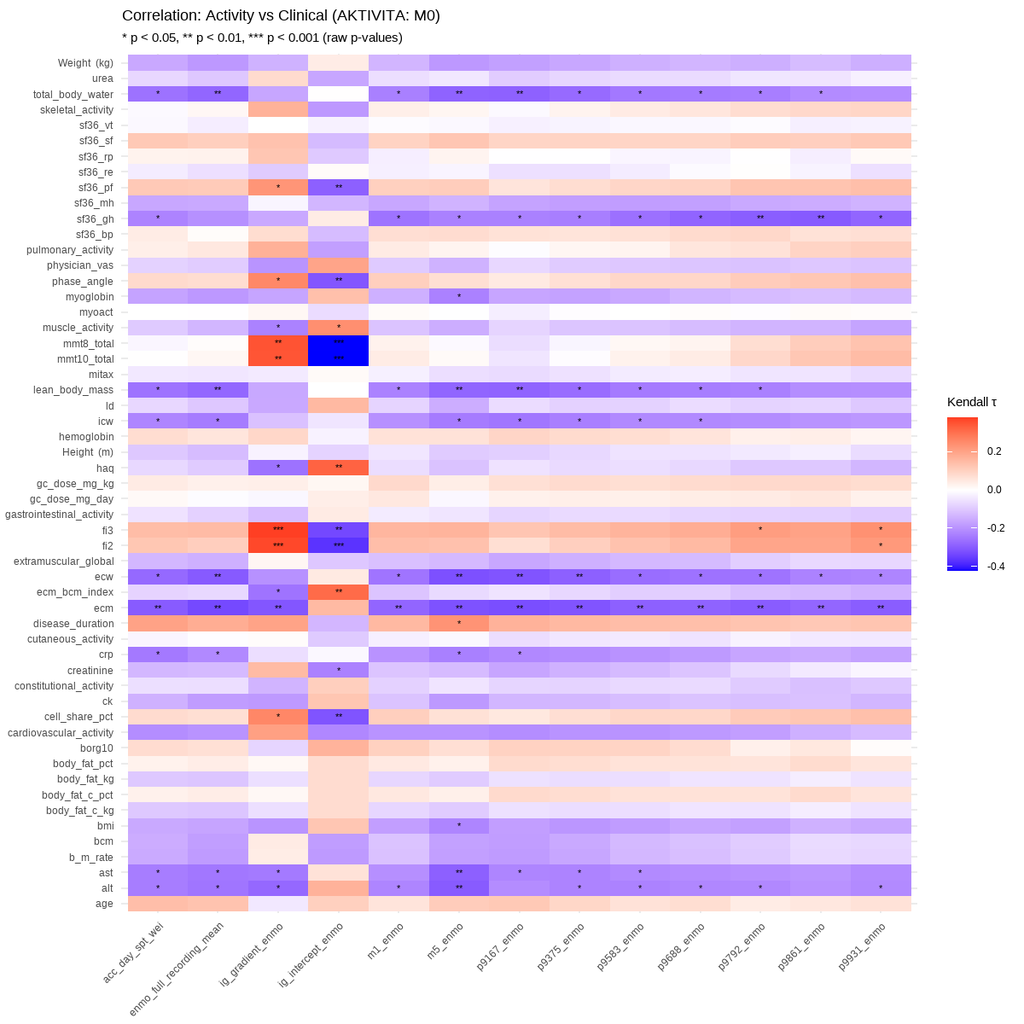

**Co vidíme:** Nejsilnější korelace aktivity s klinickými proměnnými v M0.

| Aktivita | Klinika | Korelace | p-hodnota | Signif. |
| --- | --- | --- | --- | --- |
| ig_intercept_enmo | mmt10_total | -0.4225518 | 0.0001044 | *** |
| ig_intercept_enmo | mmt8_total | -0.4223213 | 0.0001155 | *** |
| ig_gradient_enmo | fi3 | 0.3781131 | 0.0004885 | *** |
| ig_intercept_enmo | fi2 | -0.3680844 | 0.0006131 | *** |
| ig_gradient_enmo | fi2 | 0.3661808 | 0.0006629 | *** |
| ig_gradient_enmo | mmt8_total | 0.3511500 | 0.0013633 | ** |

**Jak to číst:** Vyšší absolutní korelace ukazují nejpevnější vazby v klidové fázi (M0). **Co to znamená pro myozitidy:** Pokud se mezi top páry objevují funkční skóry (MMT/HAQ/SF‑36) a zánětlivé markery, odpovídá to literatuře o vazbě mezi svalovou funkcí a aktivitou nemoci. **Co je nejisté:** Korelace neznamená kauzalitu a mohou být ovlivněny léčbou či komorbiditami. **Jaký další krok:** Ověřit, zda tyto páry přetrvávají i v M6.

### 3.2.2 M6

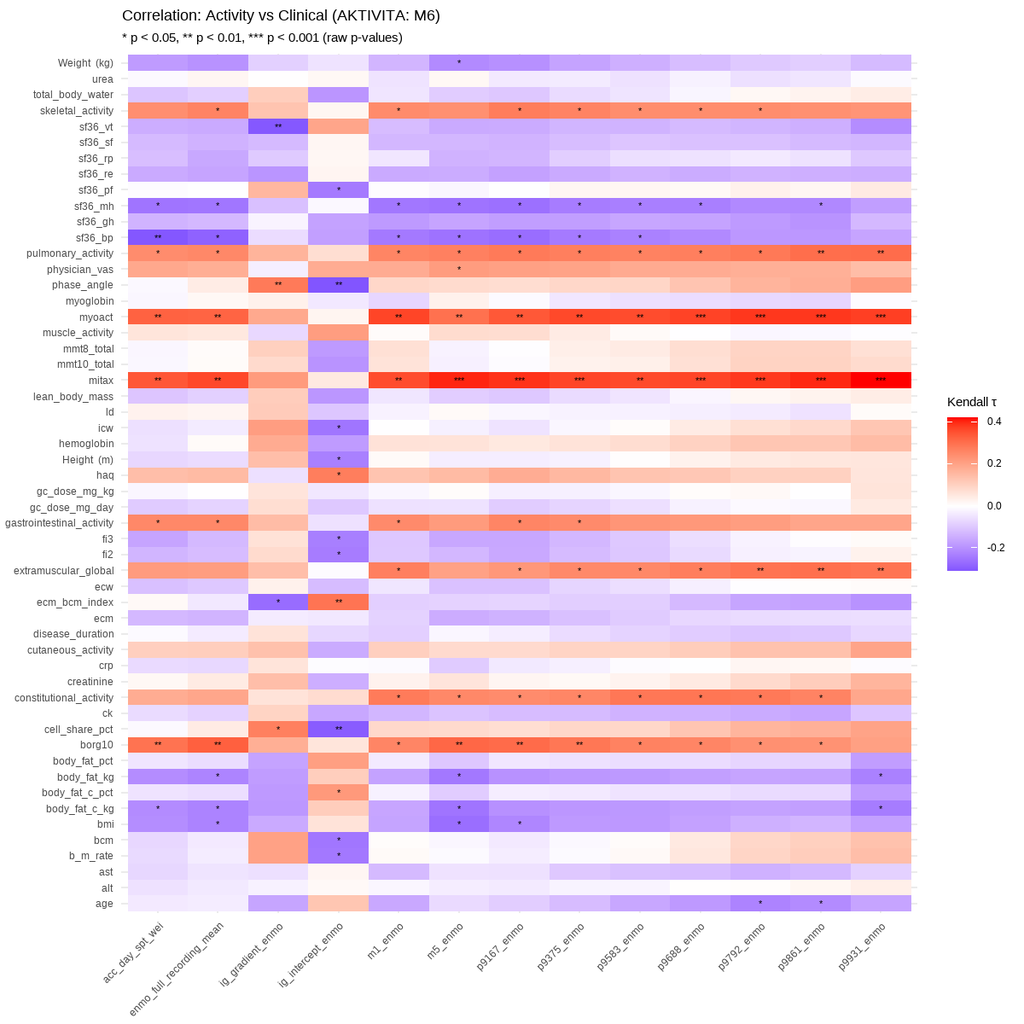

**Co vidíme:** Nejsilnější korelace aktivity s klinickými proměnnými v M6.

| Aktivita | Klinika | Korelace | p-hodnota | Signif. |
| --- | --- | --- | --- | --- |
| p9931_enmo | mitax | 0.4199439 | 0.0001497 | *** |
| m5_enmo | mitax | 0.4030009 | 0.0002741 | *** |
| p9861_enmo | mitax | 0.4005805 | 0.0002983 | *** |
| p9167_enmo | mitax | 0.3908988 | 0.0004166 | *** |
| p9792_enmo | myoact | 0.3857317 | 0.0006113 | *** |
| p9861_enmo | myoact | 0.3857317 | 0.0006113 | *** |

**Jak to číst:** Změna top párů mezi M0 a M6 naznačuje dynamiku klinicko‑aktivních vazeb. **Co to znamená pro myozitidy:** Stabilní páry napříč časem ukazují robustní biologické vztahy; změny mohou odrážet léčebnou odpověď nebo progresi. **Co je nejisté:** Interpretace je citlivá na velikost vzorku a chybějící data. **Jaký další krok:** Porovnat M0 vs. M6 statisticky a hodnotit klinickou relevanci.

### 3.2.3 Všechny návštěvy (M0+M6)

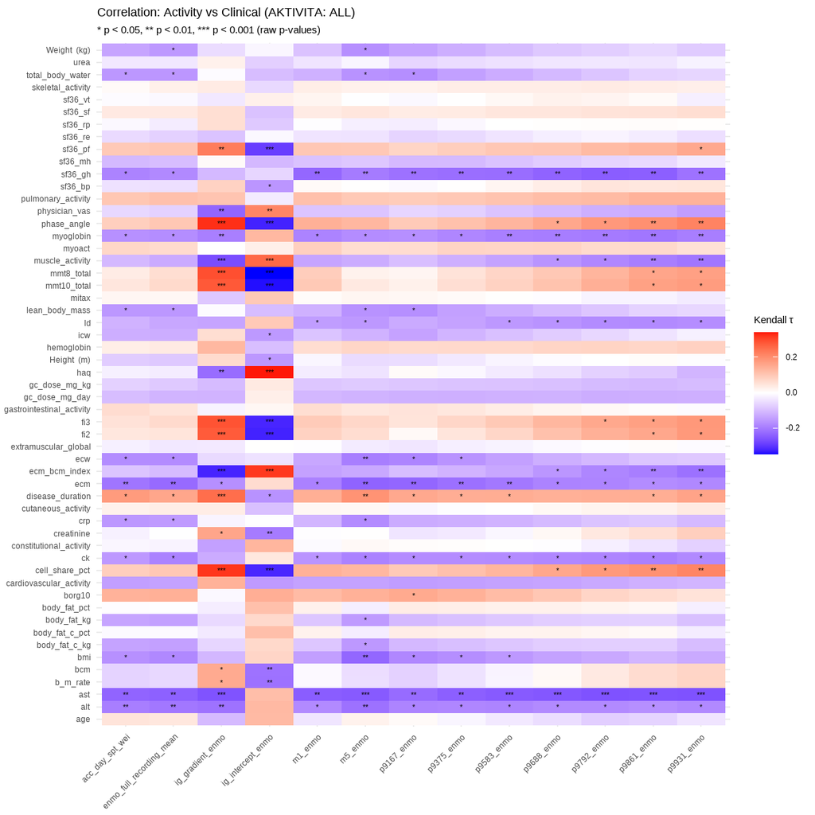

**Co vidíme:** Nejsilnější korelace aktivity s klinikou v souhrnu M0+M6.

| Aktivita | Klinika | Korelace | p-hodnota | Signif. |
| --- | --- | --- | --- | --- |
| ig_intercept_enmo | mmt8_total | -0.3476802 | 5.90e-06 | *** |
| ig_intercept_enmo | haq | 0.3403415 | 1.04e-05 | *** |
| ig_intercept_enmo | mmt10_total | -0.3400836 | 8.10e-06 | *** |
| ig_gradient_enmo | phase_angle | 0.3263642 | 1.52e-05 | *** |
| ig_intercept_enmo | fi2 | -0.3225995 | 1.46e-05 | *** |
| ig_intercept_enmo | phase_angle | -0.3225830 | 1.88e-05 | *** |

**Jak to číst:** Tento přehled ukazuje stabilní páry napříč časem, které dominují celkovému vztahu aktivity a kliniky. **Co to znamená pro myozitidy:** Stabilní korelace podporují literaturu o dlouhodobé vazbě mezi svalovou funkcí a objektivní aktivitou; mohou sloužit jako robustní kandidáti biomarkerů. **Co je nejisté:** Souhrn může maskovat rozdíly mezi M0 a M6 nebo mezi subtypy. **Jaký další krok:** Doplnit analýzu o interakce čas × subtyp a ověřit konzistenci napříč skupinami.

### 3.2.4 Změna M6–M0 (Δ)

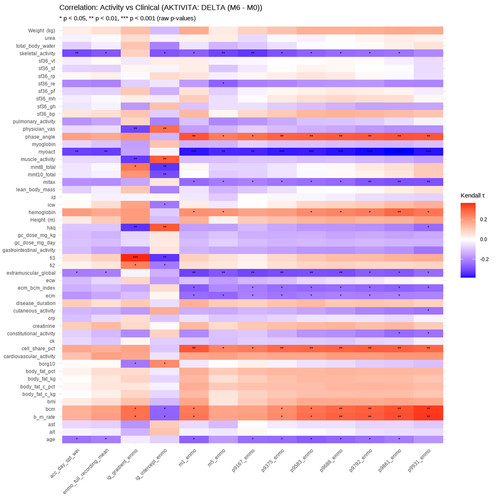

**Co vidíme:** Nejsilnější korelace mezi změnami aktivity a změnami kliniky (M6–M0).

| Aktivita | Klinika | Korelace | p-hodnota | Signif. |
| --- | --- | --- | --- | --- |
| p9861_enmo | myoact | -0.3847096 | 0.0003999 | *** |
| p9792_enmo | myoact | -0.3799892 | 0.0004710 | *** |
| p9688_enmo | myoact | -0.3729087 | 0.0006001 | *** |
| p9931_enmo | myoact | -0.3729087 | 0.0006001 | *** |
| m1_enmo | myoact | -0.3705485 | 0.0006500 | *** |
| ig_gradient_enmo | fi3 | 0.3676562 | 0.0006140 | *** |

**Jak to číst:** Pozitivní korelace znamená, že zlepšení/horšení aktivity jde stejným směrem jako změna kliniky; negativní korelace ukazuje opačný trend. **Co to znamená pro myozitidy:** Pokud se změny aktigrafie synchronizují se změnami klinických skóre, podporuje to využitelnost aktivity jako citlivého indikátoru odpovědi na léčbu. **Co je nejisté:** Změnové metriky mohou být citlivé na šum a krátkodobé výkyvy. **Jaký další krok:** Ověřit vztah změn v podskupinách (např. podle subtypu a typu léčby).

## 3.3 Kendall korelace: ČAS vs. klinika (M0/M6)

### 3.3.1 M0

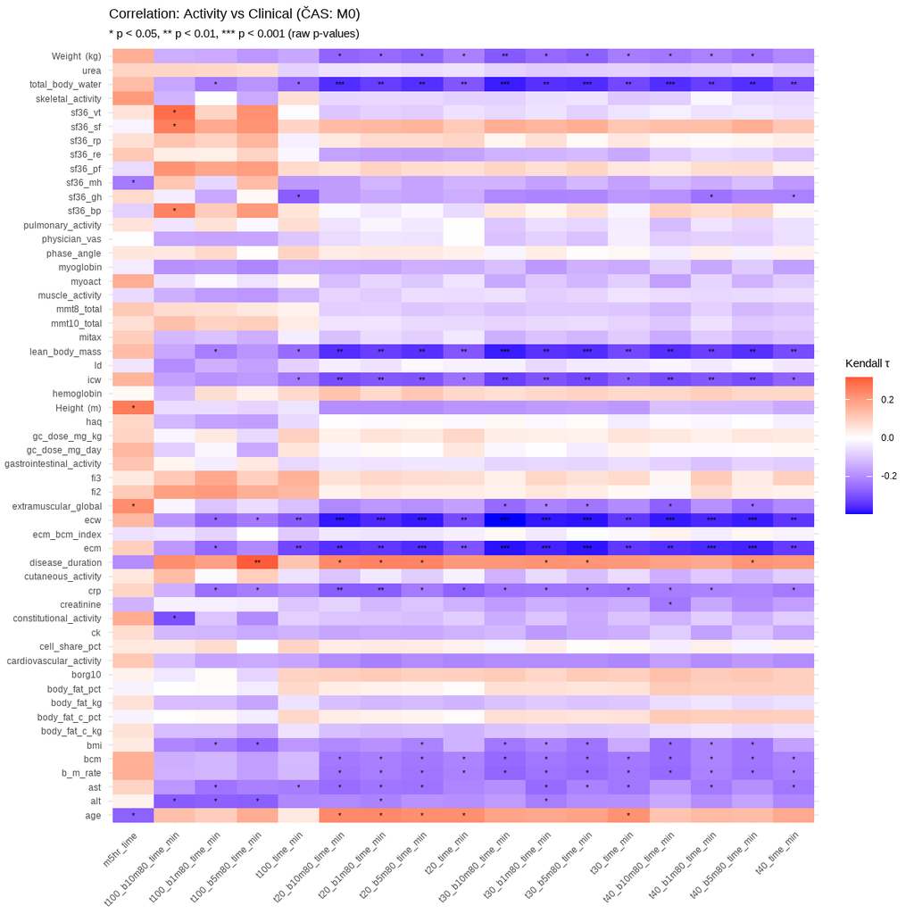

**Co vidíme:** Nejsilnější korelace časových metrik s klinickými proměnnými v M0.

| Čas | Klinika | Korelace | p-hodnota | Signif. |
| --- | --- | --- | --- | --- |
| t30_b10m80_time_min | ecw | -0.3960348 | 0.0002368 | *** |
| t30_b5m80_time_min | ecw | -0.3843524 | 0.0003601 | *** |
| t30_b10m80_time_min | ecm | -0.3839447 | 0.0003476 | *** |
| t30_b5m80_time_min | ecm | -0.3816178 | 0.0003776 | *** |
| t20_b10m80_time_min | ecw | -0.3796794 | 0.0004245 | *** |
| t30_b1m80_time_min | ecw | -0.3796794 | 0.0004245 | *** |

**Jak to číst:** Časové metriky s největší korelací mohou odrážet denní režim, únavu nebo omezení aktivity. **Co to znamená pro myozitidy:** Literatura ukazuje, že pacienti s vyšší aktivitou nemoci často vykazují nižší intenzitu a kratší dobu vyšší aktivity. **Co je nejisté:** Časové metriky mohou být ovlivněny spánkem a pracovním režimem. **Jaký další krok:** Doplnit o spánkové ukazatele a kontrolu režimových faktorů.

### 3.3.2 M6

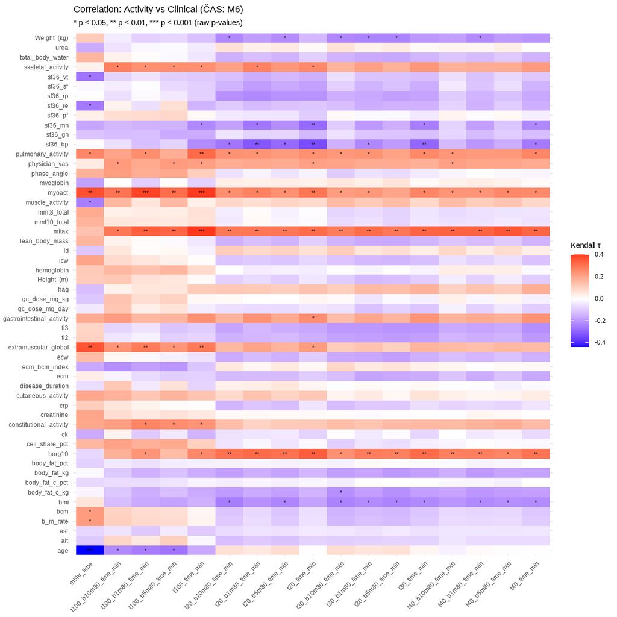

**Co vidíme:** Nejsilnější korelace časových metrik s klinikou v M6.

| Čas | Klinika | Korelace | p-hodnota | Signif. |
| --- | --- | --- | --- | --- |
| m5hr_time | age | -0.4374643 | 0.0000459 | *** |
| t100_time_min | mitax | 0.4005805 | 0.0002983 | *** |
| t100_time_min | myoact | 0.3956541 | 0.0004402 | *** |
| t100_b1m80_time_min | myoact | 0.3857317 | 0.0006113 | *** |
| m5hr_time | myoact | 0.3690110 | 0.0010648 | ** |
| m5hr_time | extramuscular_global | 0.3631097 | 0.0010625 | ** |

**Jak to číst:** Změny v top korelacích proti M0 naznačují časovou dynamiku vztahů. **Co to znamená pro myozitidy:** Pokud některé časové metriky zůstávají stabilní, mohou být vhodné jako biomarkery. **Co je nejisté:** Možná heterogenita mezi subtypy a léčebnými režimy. **Jaký další krok:** Stratifikovat analýzu podle subtypu a odpovědi na léčbu.

### 3.3.3 Všechny návštěvy (M0+M6)

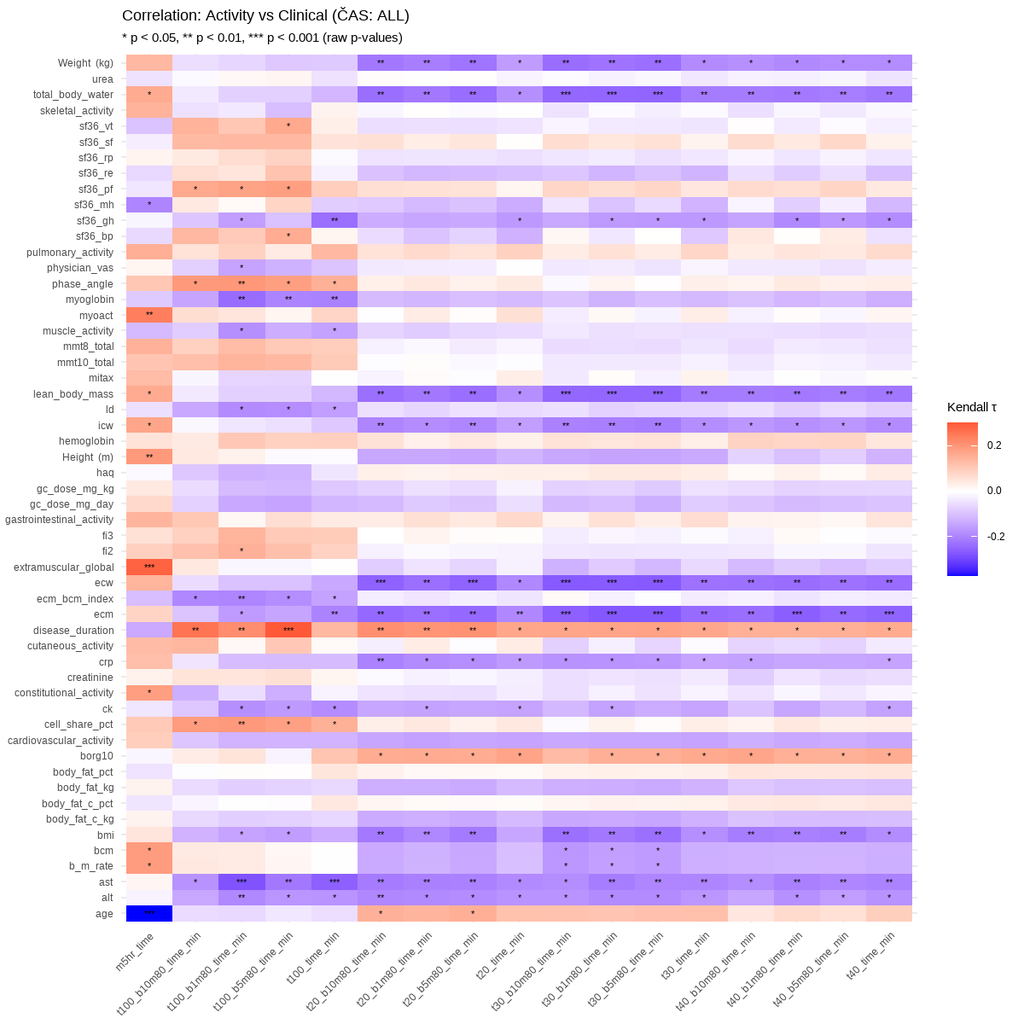

**Co vidíme:** Nejsilnější korelace časových metrik s klinikou v souhrnu M0+M6.

| Čas | Klinika | Korelace | p-hodnota | Signif. |
| --- | --- | --- | --- | --- |
| m5hr_time | age | -0.3726479 | 0.0000005 | *** |
| t100_b5m80_time_min | disease_duration | 0.3016445 | 0.0000813 | *** |
| m5hr_time | extramuscular_global | 0.2858107 | 0.0001696 | *** |
| t100_b1m80_time_min | ast | -0.2774041 | 0.0001984 | *** |
| t30_b1m80_time_min | ecm | -0.2709384 | 0.0002693 | *** |
| t30_b5m80_time_min | ecm | -0.2695405 | 0.0002902 | *** |

**Jak to číst:** Přehled zvýrazňuje časové ukazatele, které dlouhodobě souvisejí s klinickými parametry. **Co to znamená pro myozitidy:** Stabilní vazby mezi denním rytmem a klinikou podporují koncept, že režimové metriky reflektují funkční omezení a únavu popsané v literatuře IIM. **Co je nejisté:** Souhrnné korelace mohou skrývat opačné trendy u jednotlivých subtypů. **Jaký další krok:** Rozdělit analýzu podle subtypu a porovnat, které vazby zůstávají konzistentní.

### 3.3.4 Změna M6–M0 (Δ)

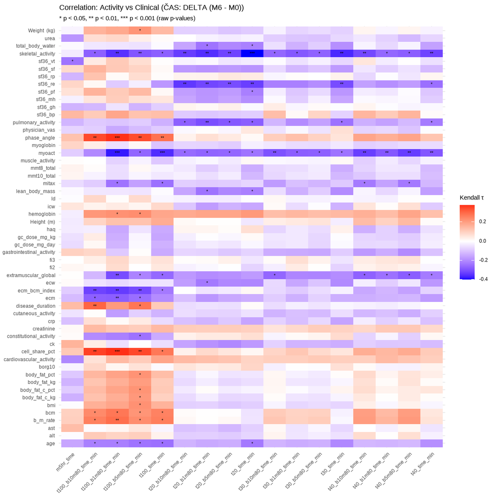

**Co vidíme:** Nejsilnější korelace mezi změnami časových metrik a změnami kliniky (M6–M0).

| Čas | Klinika | Korelace | p-hodnota | Signif. |
| --- | --- | --- | --- | --- |
| t20_time_min | skeletal_activity | -0.4001757 | 0.0004168 | *** |
| t100_b1m80_time_min | myoact | -0.3823494 | 0.0004341 | *** |
| t100_b1m80_time_min | cell_share_pct | 0.3741282 | 0.0005014 | *** |
| t100_b1m80_time_min | phase_angle | 0.3730391 | 0.0005597 | *** |
| t30_time_min | skeletal_activity | -0.3642625 | 0.0013158 | ** |
| t100_time_min | myoact | -0.3587476 | 0.0009625 | *** |

**Jak to číst:** Pozitivní korelace ukazují, že změny rytmu jdou stejným směrem jako klinické změny; negativní korelace ukazují opačnou dynamiku. **Co to znamená pro myozitidy:** Pokud změny časového profilu odpovídají změnám kliniky, mohou být časové metriky citlivým indikátorem odpovědi na terapii a únavy. **Co je nejisté:** Změnové metriky jsou citlivé na chybějící data a krátkodobé výkyvy režimu. **Jaký další krok:** Ověřit robustnost na delším sledování a při kontrole spánkových parametrů.

## 3.4 rCCA: AKTIVITA (M0/M6)

### 3.4.1 Kanonické variáty – rozptyl (komponenta 1)

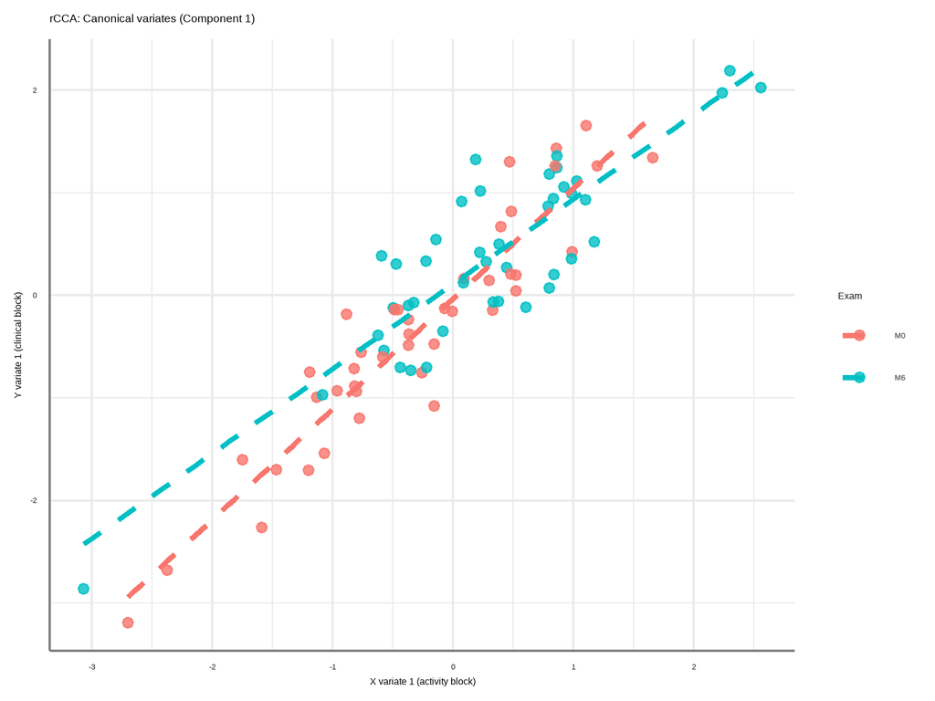

**Co vidíme:** Korelace mezi X1 a Y1 je 0.91. M0 (n=42) má medián X1 -0.37 a Y1 -0.31, M6 (n=42) má medián X1 0.31 a Y1 0.34 (ΔX1=0.67, ΔY1=0.65).

**Jak to číst:** Směr posunu M0→M6 ukazuje, zda se aktivita a klinika posouvají stejným směrem na společné ose. Na osu nejvíc přispívají aktigrafické proměnné `m5_enmo, ig_gradient_enmo, ig_intercept_enmo` a klinické proměnné `pq1, ast, disease_subtype0`.

**Co to znamená pro myozitidy:** V literatuře IIM se s vyšší aktivitou nemoci typicky pojí nižší denní aktivita a horší funkční skóry (MMT8, HAQ, SF-36 PF). Posun na ose rCCA zde naznačuje, že aktigrafie zachycuje část klinické variability konzistentní s tímto vzorcem.

**Co je nejisté:** Vztah je lineární a může přehlédnout nelineární dynamiku nebo vliv léčby v jednotlivých subtytech.

**Jaký další krok:** Ověřit robustnost posunu mezi M0/M6 pomocí resamplingu a stratifikace podle subtypů.

### 3.4.2 Korelace proměnných s kanonickou osou

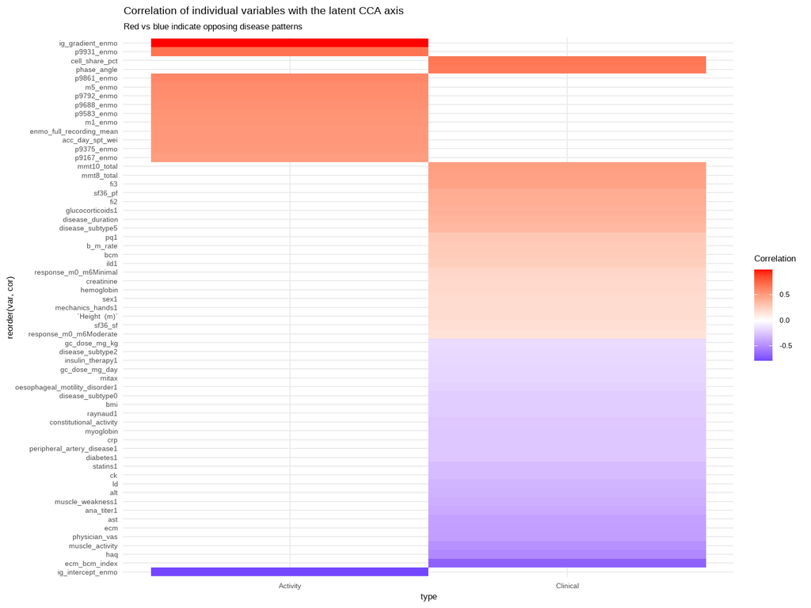

**Co vidíme:** Korelace jednotlivých proměnných s kanonickou osou pro aktivitu i kliniku.

[output not shown]

| Klinika | Korelace | Směr |
| --- | --- | --- |
| cell_share_pct | 0.6743398 | pozitivní |
| phase_angle | 0.6608346 | pozitivní |
| mmt10_total | 0.4879946 | pozitivní |
| mmt8_total | 0.4817267 | pozitivní |
| ecm_bcm_index | -0.6720217 | negativní |
| haq | -0.5066239 | negativní |
| muscle_activity | -0.4684377 | negativní |
| physician_vas | -0.4050998 | negativní |

**Jak to číst:** Pozitivní korelace znamená, že vyšší hodnota proměnné zvyšuje skóre kanonické osy; negativní korelace jej snižuje. **Co to znamená pro myozitidy:** Proměnné s vysokou korelací s osou často odpovídají klinicky významným doménám (svalová síla, funkce, zánětlivé markery), což je v souladu s literaturou IIM. **Co je nejisté:** Korelace neodlišují přímý vliv od spoluvýskytu a mohou být ovlivněny škálováním. **Jaký další krok:** Ověřit stabilitu pořadí proměnných při resamplingu.

### 3.4.3 Heatmapa korelací top‑loading proměnných

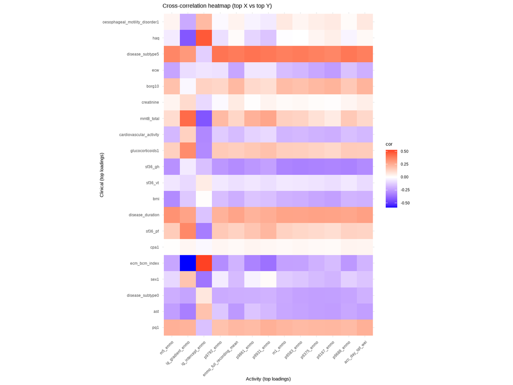

**Co vidíme:** Heatmapa vizualizuje korelace mezi top aktigrafickými a klinickými proměnnými. Nejsilnější páry jsou uvedeny níže.

| Aktivita | Klinika | Korelace |
| --- | --- | --- |
| ig_gradient_enmo | ecm_bcm_index | -0.5885354 |
| ig_intercept_enmo | ecm_bcm_index | 0.5238677 |
| ig_intercept_enmo | haq | 0.4764840 |
| ig_gradient_enmo | mmt8_total | 0.4338500 |
| ig_intercept_enmo | mmt8_total | -0.4320137 |
| ig_gradient_enmo | haq | -0.4272955 |

**Jak to číst:** Silné absolutní korelace indikují proměnné, které se pohybují společně a definují dominantní klinicko‑aktivní vzorec.

**Co to znamená pro myozitidy:** V literatuře je konzistentně popisována vazba mezi poklesem fyzické aktivity a horší svalovou silou či funkční kapacitou. Pokud se v top párech objevují parametry aktivity spolu s MMT/HAQ/SF‑36, jde o biologicky očekávatelný obraz.

**Co je nejisté:** Korelace mohou být ovlivněny léčbou a komorbiditami (např. plicní či kardiální postižení).

**Jaký další krok:** Ověřit, zda top páry přetrvávají po stratifikaci podle subtypu a po úpravě o věk/pohlaví.

### 3.4.4 Loadings na latentní ose (barploty)

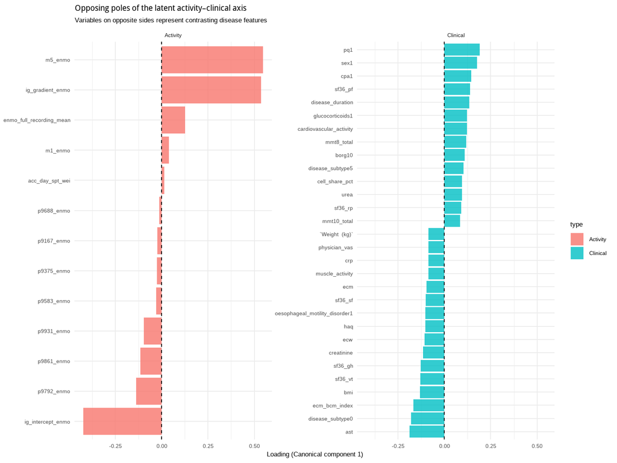

**Co vidíme:** Na pozitivním pólu aktivity dominují `m5_enmo, ig_gradient_enmo, enmo_full_recording_mean`, na negativním pólu `ig_intercept_enmo, p9792_enmo, p9861_enmo`. U kliniky jsou nejvýraznější `pq1, sex1, cpa1` vs. `ast, disease_subtype0, ecm_bcm_index`.

**Jak to číst:** Osa kontrastuje dvě klinicko‑aktivní konfigurace; proměnné s opačnými znaménky znamenají, že při růstu jedné skupiny proměnných klesá druhá.

**Co to znamená pro myozitidy:** Pokud se mezi top klinickými proměnnými objevují parametry svalové síly, bolesti či kvality života, je to v souladu s literaturou, která popisuje úzkou vazbu mezi funkčním statusem a reálnou aktivitou.

**Co je nejisté:** Loadings mohou být citlivé na výběr proměnných a na míru chybějících dat.

**Jaký další krok:** Provést stabilitní analýzu (např. bootstrap) a ověřit konzistenci pólů v M0 a M6.

### 3.4.5 Subtypy v prostoru rCCA (komponenta 1)

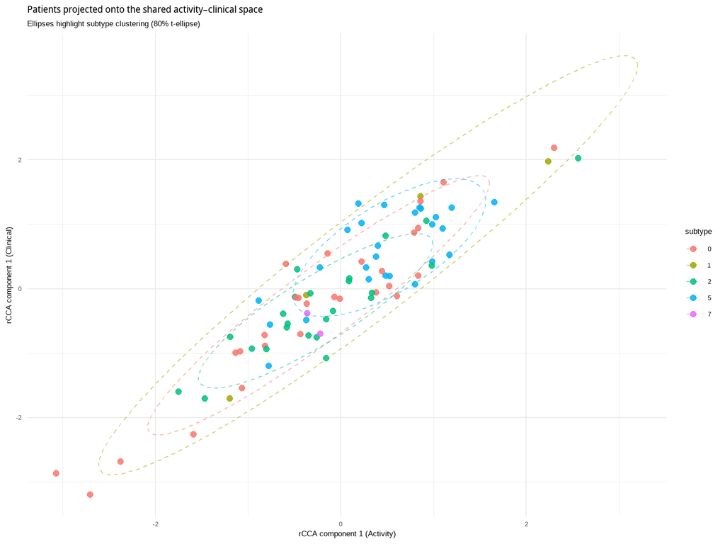

**Co vidíme:** Největší vzdálenost centroidů je mezi Subtypem 7 a 5. Na ose X je nejvýše Subtyp 5, nejníže Subtyp 0.

**Jak to číst:** Oddělení centroidů znamená, že kombinace aktivity a kliniky má různý profil napříč subtypy.

**Co to znamená pro myozitidy:** V literatuře je opakovaně popsána heterogenita IIM subtypů v síle, funkci a orgánovém postižení; rozdílná poloha v rCCA prostoru je s tím konzistentní.

**Co je nejisté:** Malý počet pacientů v některých subtypech může zhoršit stabilitu centroidů.

**Jaký další krok:** Ověřit separaci v M0 a M6 zvlášť a propojit s klinickými endpointy.

### 3.4.6 Tabulka: Top loadings (komponenta 1)

| Klinika – proměnná | Loading |
| --- | --- |
| pq1 | 0.1918491 |
| ast | -0.1885039 |
| disease_subtype0 | -0.1798083 |
| sex1 | 0.1756219 |
| ecm_bcm_index | -0.1675569 |
| cpa1 | 0.1452474 |
| sf36_pf | 0.1383371 |
| disease_duration | 0.1354107 |
| bmi | -0.1313276 |
| sf36_vt | -0.1296291 |

**Co vidíme:** Nejvýznamnější proměnné aktivity a kliniky, které definují osu rCCA.  
**Jak to číst:** Vyšší absolutní loading = silnější příspěvek k ose; znaménko určuje směr.  
**Co to znamená pro myozitidy:** Vysoko‑naložené proměnné mohou sloužit jako kandidátní biomarkery sdíleného fenotypu.  
**Co je nejisté:** Číselné pořadí se může měnit při drobných změnách dat nebo imputace.  
**Jaký další krok:** Ověřit stabilitu top‑proměnných v resamplingu.

## 3.5 rCCA: ČAS (M0/M6)

### 3.5.1 Kanonické variáty – rozptyl (komponenta 1)

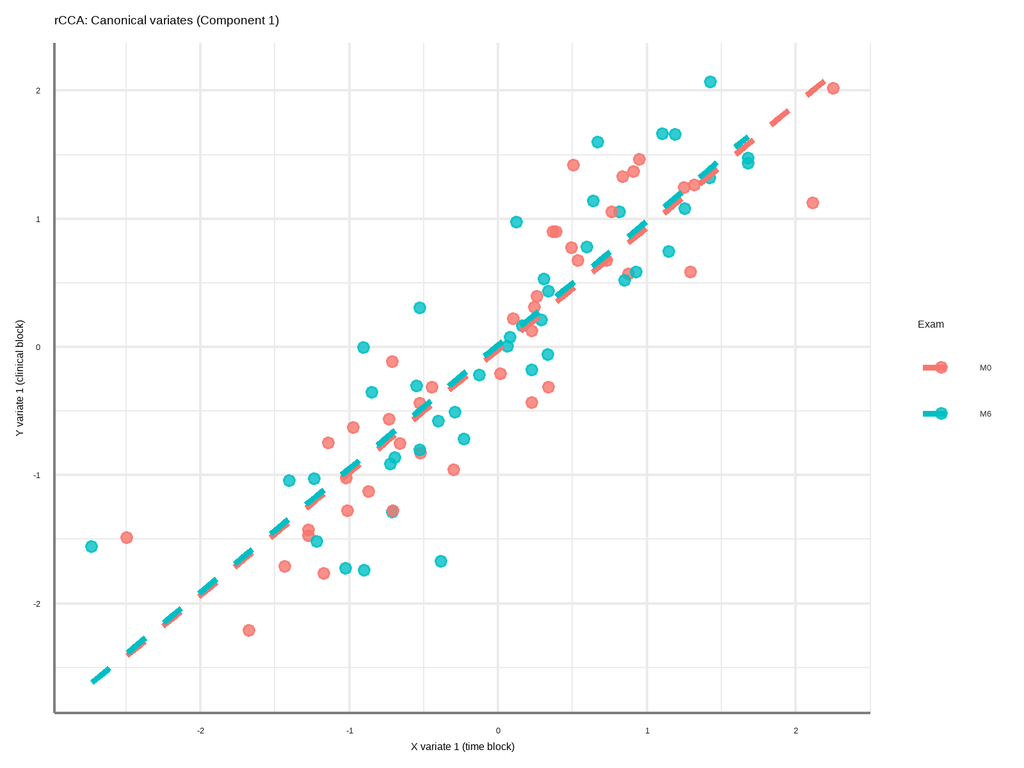

**Co vidíme:** Korelace mezi X1 a Y1 je 0.89. M0 (n=42) má medián X1 0.16 a Y1 -0.16, M6 (n=42) má medián X1 0.10 a Y1 0.04 (ΔX1=-0.06, ΔY1=0.20).

**Jak to číst:** Časové metriky s největším vlivem na osu jsou `t100_time_min, m5hr_time, t100_b1m80_time_min`; klinická osa je definována proměnnými `age, disease_duration, borg10`.

**Co to znamená pro myozitidy:** V literatuře se narušený denní rytmus a nízká intenzita aktivity často pojí s vyšší nemocenskou aktivitou a horší kvalitou života. Posun M0→M6 proto může odrážet klinicky relevantní změny režimu nebo únavy.

**Co je nejisté:** Časové metriky mohou být ovlivněny režimem pacienta mimo nemoc (práce, spánek).

**Jaký další krok:** Ověřit přidanou hodnotu časových metrik oproti agregované aktivitě a zahrnout spánkové parametry.

### 3.5.2 Korelace proměnných s kanonickou osou

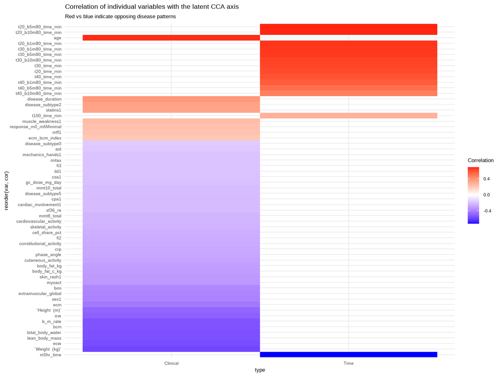

**Co vidíme:** Korelace časových a klinických proměnných s kanonickou osou.

[output not shown]

| Klinika | Korelace | Směr |
| --- | --- | --- |
| age | 0.6754591 | pozitivní |
| disease_duration | 0.3832624 | pozitivní |
| disease_subtype2 | 0.3427489 | pozitivní |
| statins1 | 0.3388143 | pozitivní |
| `Weight (kg)` | -0.5746184 | negativní |
| ecw | -0.5546368 | negativní |
| lean_body_mass | -0.5404626 | negativní |
| total_body_water | -0.5403825 | negativní |

**Jak to číst:** Pozitivní korelace zvyšuje skóre osy, negativní korelace jej snižuje. **Co to znamená pro myozitidy:** Pokud se mezi top časovými proměnnými objevují metriky rytmu a variability, odpovídá to literatuře o poruše denního režimu a únavě u IIM. **Co je nejisté:** Korelace mohou být ovlivněny režimem pacienta mimo nemoc. **Jaký další krok:** Ověřit konzistenci při kontrole spánkových a pracovních faktorů.

### 3.5.3 Heatmapa korelací top‑loading proměnných

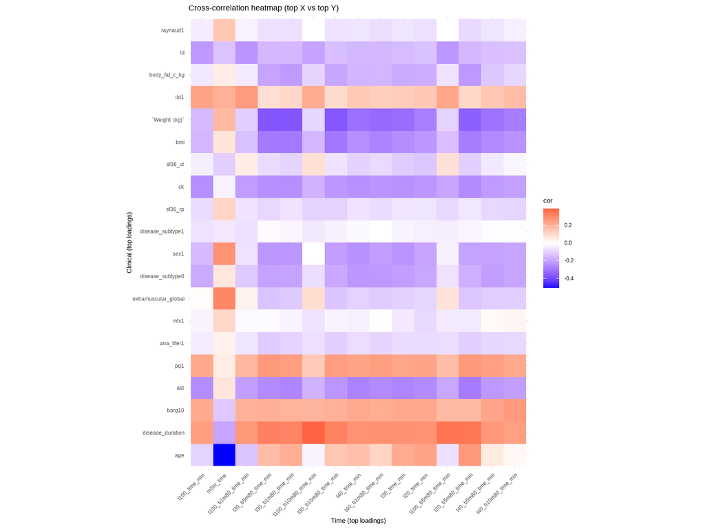

**Co vidíme:** Heatmapa zvýrazňuje top vztahy mezi časovými metrikami a klinikou; nejvyšší korelace jsou uvedeny níže.

| Čas | Klinika | Korelace |
| --- | --- | --- |
| m5hr_time | age | -0.5060747 |
| t100_b10m80_time_min | disease_duration | 0.3884954 |
| t30_b1m80_time_min | `Weight (kg)` | -0.3691278 |
| t30_b5m80_time_min | `Weight (kg)` | -0.3689819 |
| t30_b10m80_time_min | `Weight (kg)` | -0.3670203 |
| t100_b5m80_time_min | disease_duration | 0.3533944 |

**Jak to číst:** Časové metriky s největšími absolutními korelacemi mohou odrážet klinicky významné změny denního rytmu nebo únavy.

**Co to znamená pro myozitidy:** Literatura u IIM popisuje, že dysregulace denních režimů a zvýšená únava souvisí s horší funkcí a kvalitou života; to odpovídá přítomnosti časových metrik mezi nejvýraznějšími korelacemi.

**Co je nejisté:** Vztahy mohou být zkresleny chováním mimo nemoc (práce, spánek, sezónnost).

**Jaký další krok:** Doplnit analýzu o spánkové ukazatele a stratifikovat podle pracovního režimu.

### 3.5.4 Loadings na latentní ose (barploty)

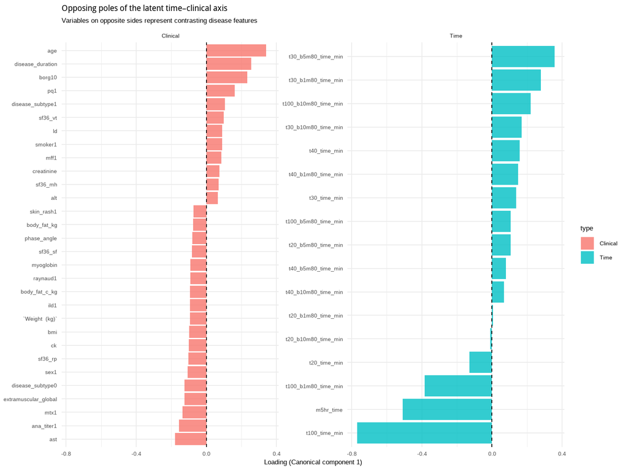

**Co vidíme:** Na časové straně osy dominují `t30_b5m80_time_min, t30_b1m80_time_min, t100_b10m80_time_min` a na opačném pólu `t100_time_min, m5hr_time, t100_b1m80_time_min`. Na klinické straně jsou nejvýraznější `age, disease_duration, borg10` vs. `ast, ana_titer1, mtx1`.

**Jak to číst:** Osa odděluje pacienty s odlišným časovým profilem aktivity a klinickým stavem.

**Co to znamená pro myozitidy:** U myozitid je v literatuře popisováno, že narušení denního režimu a zvýšená únava se promítají do funkčních skóre; časové metriky proto mohou být klinicky relevantní.

**Co je nejisté:** Časové ukazatele mohou být citlivé na krátkodobé změny režimu nebo komorbidity.

**Jaký další krok:** Validovat časové metriky na delším sledování a s kontrolou spánku.

### 3.5.5 Subtypy v prostoru rCCA (komponenta 1)

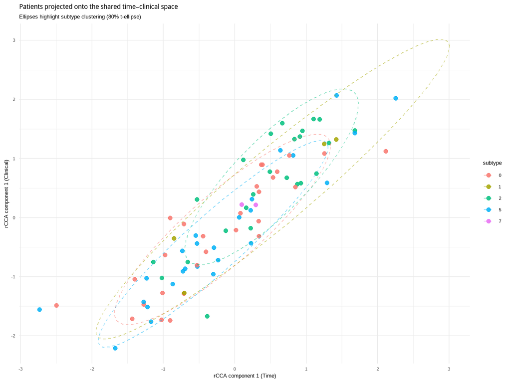

**Co vidíme:** Největší vzdálenost centroidů je mezi Subtypem 5 a 2. Na ose X je nejvýše Subtyp 2, nejníže Subtyp 5.

**Jak to číst:** Odstupy centroidů ukazují, že časové metriky diferencují subtypy i po propojení s klinikou.

**Co to znamená pro myozitidy:** Subtypy IIM mohou mít odlišný denní režim a míru únavy, což je v literatuře spojováno s různou aktivitou nemoci a kvalitou života.

**Co je nejisté:** Časové profily jsou citlivé na externí režimové faktory.

**Jaký další krok:** Ověřit výsledky po úpravě o spánek/práci a testovat stabilitu centroidů.

### 3.5.6 Tabulka: Top loadings (komponenta 1)

| Klinika – proměnná | Loading |
| --- | --- |
| age | 0.3407094 |
| disease_duration | 0.2558388 |
| borg10 | 0.2340892 |
| ast | -0.1772360 |
| pq1 | 0.1627632 |
| ana_titer1 | -0.1553716 |
| mtx1 | -0.1357272 |
| extramuscular_global | -0.1252434 |
| disease_subtype0 | -0.1242366 |
| sex1 | -0.1070516 |

**Co vidíme:** Nejvýznamnější časové a klinické proměnné na hlavní ose rCCA.  
**Jak to číst:** Proměnné s nejvyšším absolutním loadingem dominují interpretaci.  
**Co to znamená pro myozitidy:** Tyto proměnné mohou být kandidátními markery časového profilu onemocnění.  
**Co je nejisté:** Změny v čase mohou být ovlivněny režimem pacienta mimo nemoc.  
**Jaký další krok:** Klinicky validovat, zda časové metriky zlepšují stratifikaci.

# 4 DIABLO – integrativní klasifikace subtypů

## 4.1 Vysvětlení metody (pro neodborníky)

DIABLO kombinuje více datových bloků (např. aktivita/čas + klinika) a hledá **společné latentní komponenty**, které zároveň **oddělují subtypy**. Výsledkem je „signatura“ – malý soubor proměnných z každého bloku, který je pro rozlišení subtypů nejdůležitější.  
*Klinický příklad:* Pokud Subtyp 2 má konzistentně jiný vzorec aktivity a klinických hodnot než Subtyp 1, DIABLO identifikuje nejvíce diskriminační proměnné.

## 4.2 DIABLO: AKTIVITA (M0/M6)

### 4.2.1 Separace subtypů v latentním prostoru

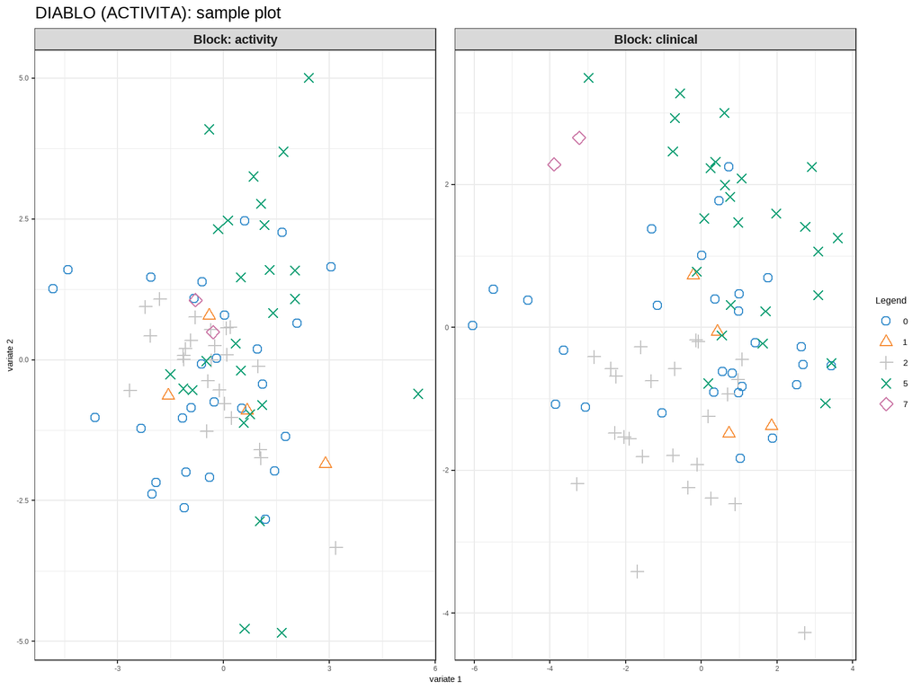

**Co vidíme:** Největší vzdálenost mezi centroidy má Subtyp 7 vs Subtyp 1 (vzdálenost 1.71). Na ose 1 je nejvýše Subtyp 5 a nejníže Subtyp 7. Chybovost klasifikace (centroids.dist) je 69.6 %.

**Jak to číst:** Zřetelnější separace centroidů znamená, že aktigrafický blok nese signál rozlišující subtypy.

**Co to znamená pro myozitidy:** Heterogenita subtypů (např. rozdílné postižení svalů či plic) je dobře popsaná v literatuře a může se odrážet i v denní aktivitě.

**Co je nejisté:** Kvalita separace závisí na počtu vzorků v jednotlivých subtypech.

**Jaký další krok:** Ověřit stabilitu separace na bootstrapu a v rámci M0/M6 zvlášť.

### 4.2.2 Proměnné aktivity v DIABLO (correlation circle)

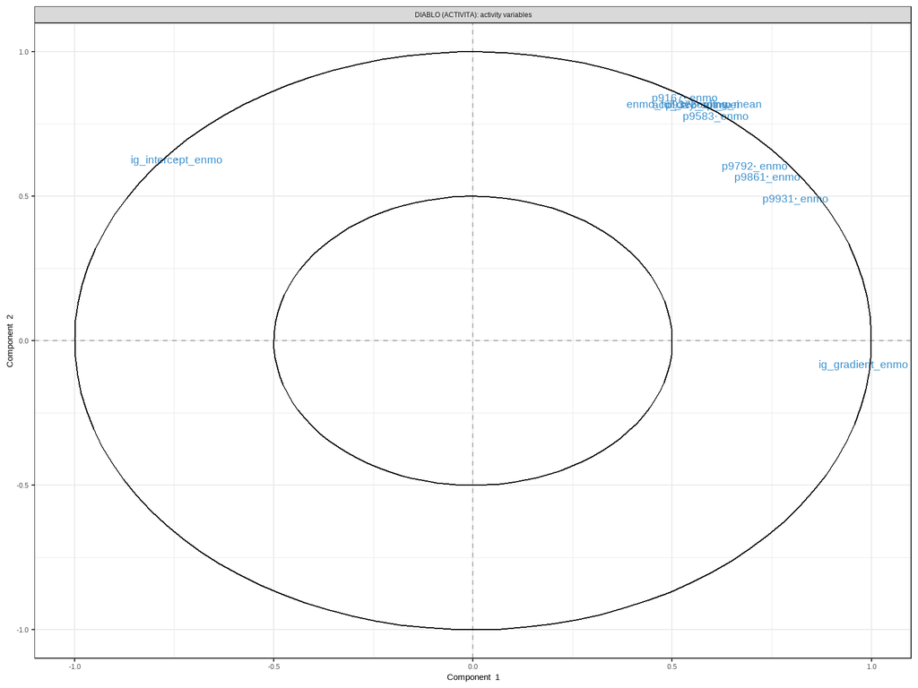

**Co vidíme:** Mezi nejsilnější aktigrafické proměnné patří `ig_gradient_enmo, ig_intercept_enmo, p9931_enmo, p9861_enmo, p9792_enmo` (|loading| v rozsahu 0.14–0.77).

**Jak to číst:** Proměnné dál od středu přispívají nejvíc k separaci subtypů v latentním prostoru.

**Co to znamená pro myozitidy:** V literatuře je snížená denní aktivita a změněná intenzita aktivity spojována s vyšší nemocenskou aktivitou a slabší svalovou funkcí, což odpovídá tomu, že aktigrafie patří mezi hlavní diskriminační signály.

**Co je nejisté:** Výběr proměnných závisí na `keepX` a může se měnit při resamplingu.

**Jaký další krok:** Prověřit stabilitu výběru pomocí opakované CV a případně upravit `keepX`.

### 4.2.3 Proměnné kliniky v DIABLO (correlation circle)

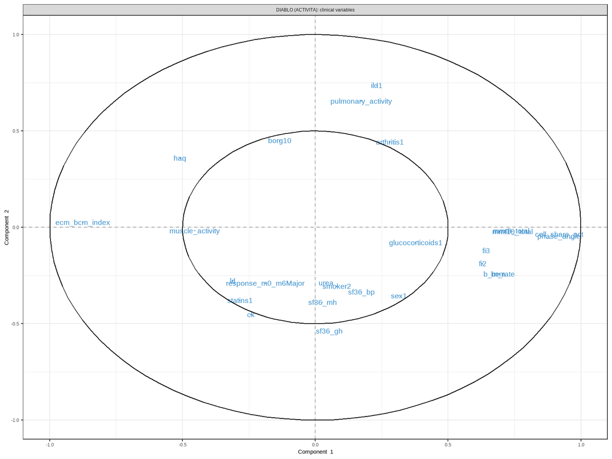

**Co vidíme:** Nejvýraznější klinické proměnné v komponentě 1 jsou `cell_share_pct, phase_angle, ecm_bcm_index, mmt8_total, mmt10_total` (|loading| 0.33–0.49).

**Jak to číst:** Směr a vzdálenost od středu ukazují, jak proměnné přispívají k separaci subtypů.

**Co to znamená pro myozitidy:** Klinické domény jako svalová síla, funkční skóry či plicní postižení jsou v literatuře klíčové pro fenotypizaci IIM; proto dává smysl, že se objevují mezi top proměnnými.

**Co je nejisté:** Klinické proměnné mohou být silně korelované a interpretace jednotlivých loadingů musí brát v úvahu redundanci.

**Jaký další krok:** Validovat signaturu na nezávislé kohortě a porovnat s klinickou klasifikací.

### 4.2.4 CIM signatura (aktivita + klinika)

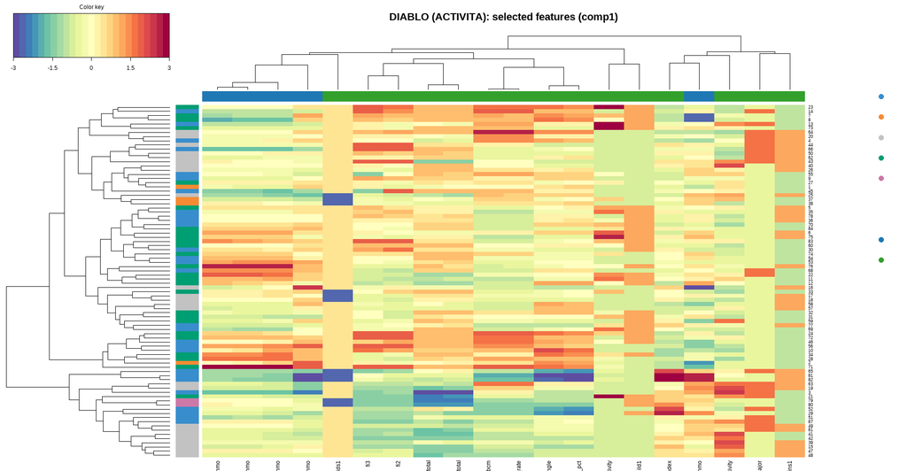

**Jak to číst:** Kompaktní bloky barev znamenají konzistentní signaturu; rozpad do více bloků ukazuje heterogenitu.

**Co to znamená pro myozitidy:** Kombinovaná signatura aktivity a kliniky odpovídá literatuře, která zdůrazňuje multifaktoriální povahu IIM fenotypů.

**Co je nejisté:** Vzorce mohou být citlivé na škálování a zvolený počet proměnných (`keepX`).

**Jaký další krok:** Ověřit stabilitu klastrů na bootstrapu a testovat signaturu v externí kohortě.

### 4.2.5 Tabulka: Vybrané proměnné (komponenta 1)

| Klinika – proměnná | Loading |
| --- | --- |
| cell_share_pct | 0.494526048 |
| phase_angle | 0.479424044 |
| ecm_bcm_index | -0.476917275 |
| mmt8_total | 0.343378627 |
| mmt10_total | 0.332776391 |
| fi3 | 0.206555798 |
| statins1 | -0.102859777 |
| fi2 | 0.076212588 |
| muscle_activity | -0.066705921 |
| ild1 | 0.049980902 |
| pulmonary_activity | 0.040509528 |
| glucocorticoids1 | 0.033558393 |
| response_m0_m6Major | -0.023878617 |
| b_m_rate | 0.011031656 |
| bcm | 0.006070004 |

**Co vidíme:** Konkrétní proměnné tvořící signaturu pro rozlišení subtypů.  
**Jak to číst:** Vyšší absolutní loading znamená větší diskriminační sílu.  
**Co to znamená pro myozitidy:** Tyto proměnné mají potenciál stát se biomarkerovým panelem subtypů.  
**Co je nejisté:** Signatura může být závislá na volbě počtu komponent.  
**Jaký další krok:** Provést externí validaci a testovat klinickou použitelnost.

## 4.3 DIABLO: ČAS (M0/M6)

### 4.3.1 Separace subtypů v latentním prostoru

[figure not shown]

**Co vidíme:** Největší vzdálenost centroidů je mezi Subtyp 5 a Subtyp 2 (vzdálenost 1.76). Na ose 1 je nejvýše Subtyp 0, nejníže Subtyp 7. Chybovost klasifikace (centroids.dist) je 65.0 %.

**Jak to číst:** Časové metriky rozlišují subtypy, pokud jsou centroidy dobře oddělené.

**Co to znamená pro myozitidy:** Denní režim a úroveň aktivity se v IIM často liší mezi subtypy a mohou reflektovat specifické klinické postižení (např. svalové vs. plicní).

**Co je nejisté:** Časové metriky jsou citlivé na chování mimo nemoc (práce, spánek).

**Jaký další krok:** Ověřit robustnost po úpravě o věk, pohlaví a léčbu.

### 4.3.2 Proměnné času v DIABLO (correlation circle)

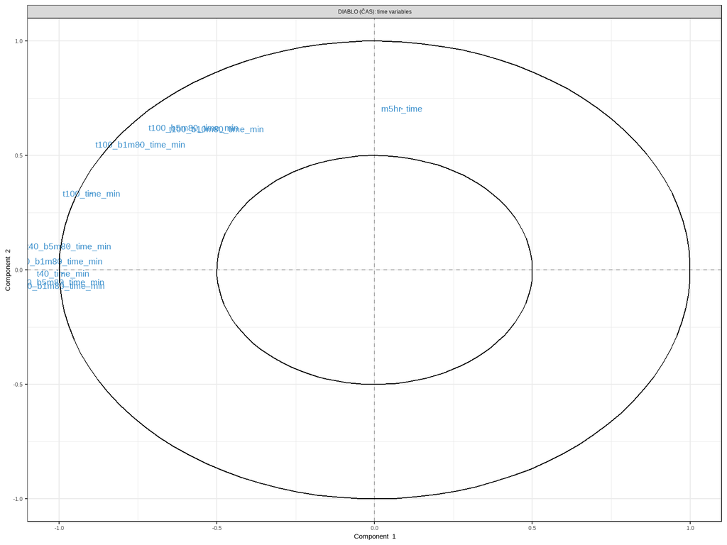

**Co vidíme:** Nejvýraznější časové proměnné v komponentě 1 jsou `t40_b1m80_time_min, t40_time_min, t30_b5m80_time_min, t40_b5m80_time_min, t30_b1m80_time_min` (|loading| 0.17–0.64).

**Jak to číst:** Proměnné s vyšším absolutním loadingem nesou větší část signálu pro separaci subtypů.

**Co to znamená pro myozitidy:** Rytmické a časové ukazatele aktivity mohou odrážet únavu a funkční omezení, což je v literatuře IIM často spojováno s klinickým postižením.

**Co je nejisté:** Časové metriky mohou být ovlivněny externími faktory a krátkodobými výkyvy.

**Jaký další krok:** Prověřit stabilitu výběru při různých nastaveních prahů a subsamplingu.

### 4.3.3 Proměnné kliniky v DIABLO (correlation circle)

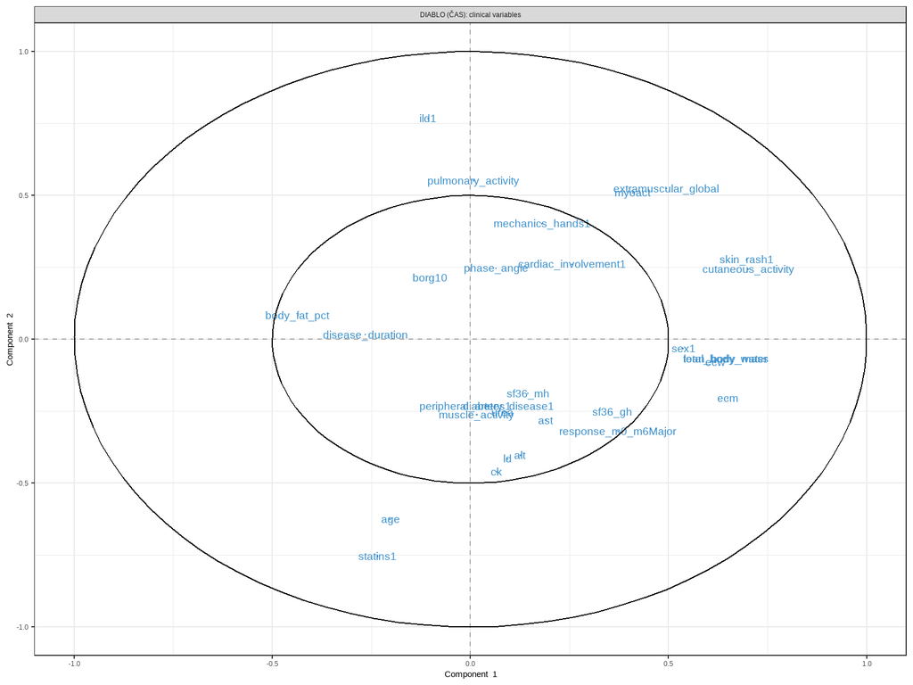

**Co vidíme:** Nejvýraznější klinické proměnné v komponentě 1 jsou `cutaneous_activity, skin_rash1, ecm, response_m0_m6Major, sf36_gh` (|loading| 0.30–0.56).

**Jak to číst:** Směr a velikost loadingu ukazují, jak klinické proměnné přispívají k rozlišení subtypů.

**Co to znamená pro myozitidy:** Časově‑klinické proměnné mohou lépe zachytit dynamiku onemocnění, např. kolísání síly či únavy, které jsou v literatuře u IIM popsané.

**Co je nejisté:** Výsledky mohou být citlivé na imputaci chybějících hodnot.

**Jaký další krok:** Otestovat alternativní imputace a porovnat stabilitu signatury.

### 4.3.4 CIM signatura (čas + klinika)

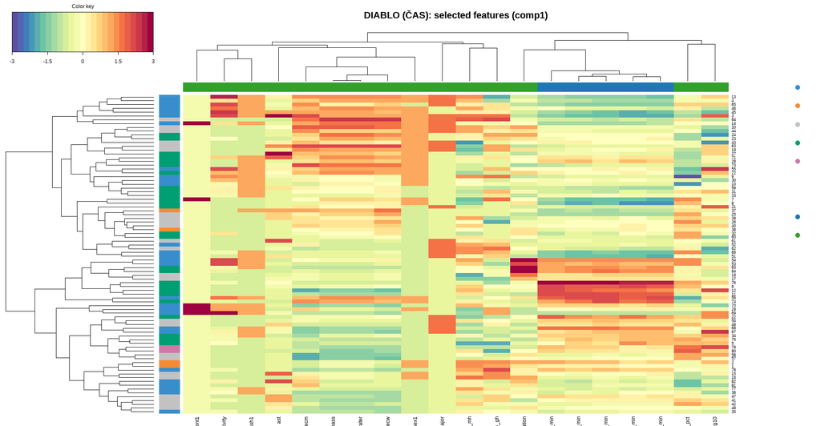

**Jak to číst:** Souvislé bloky naznačují stabilní signaturu; více bloků ukazuje heterogenitu mezi subtypy.

**Co to znamená pro myozitidy:** Časové metriky mohou zachytit únavu a režimové změny, které jsou v literatuře IIM spojeny s funkčním stavem a kvalitou života.

**Co je nejisté:** Výsledek může být citlivý na denní režim a na nastavení `keepX`.

**Jaký další krok:** Validovat signaturu na delším sledování a při kontrole spánkových faktorů.

### 4.3.5 Tabulka: Vybrané proměnné (komponenta 1)

| Klinika – proměnná | Loading |
| --- | --- |
| cutaneous_activity | 0.564417448 |
| skin_rash1 | 0.538623670 |
| ecm | 0.339277693 |
| response_m0_m6Major | 0.301585826 |
| sf36_gh | 0.297032149 |
| disease_duration | -0.208897636 |
| borg10 | -0.136288261 |
| ecw | 0.127627614 |
| lean_body_mass | 0.088680629 |
| total_body_water | 0.087587498 |
| cardiac_involvement1 | 0.050757382 |
| ast | 0.016969571 |
| sex1 | 0.011083196 |
| body_fat_pct | -0.001205668 |
| sf36_mh | 0.000334462 |

**Co vidíme:** Konkrétní časové a klinické proměnné v signatuře subtypů.  
**Jak to číst:** Kombinace proměnných ukazuje, které aspekty rytmu souvisí s klinikou.  
**Co to znamená pro myozitidy:** Může naznačovat, že časový profil je součástí fenotypu.  
**Co je nejisté:** Výsledek může být nestabilní při menších počtech vzorků.  
**Jaký další krok:** Ověřit predikční výkon na nezávislém vzorku.

# 5 MOFA – latentní faktory bez dohledu

## 5.1 Vysvětlení metody (pro neodborníky)

MOFA je metoda, která umí spojit více bloků dat (např. **klinika** + **aktivita/čas z akcelerometru**) a najít v nich **společné vzorce**.

## 5.2 Co je „factor“ (faktor)

**Faktor** je „skrytá osa“ = **souhrnné skóre**, které popisuje jeden hlavní typ rozdílu mezi pacienty.

- Každý pacient má pro každý faktor **jedno číslo**.
- Pacienti s podobným skóre mají **podobný profil** napříč daty.
- Faktor není jedna proměnná (CRP, kroky…), ale **kombinace více proměnných**, které se často mění společně.

> Znaménko (+/−) je technické (osa se může „otočit“). Důležitý je rozdíl mezi dvěma konci faktoru.

## 5.3 Co jsou „loadings“ a heatmapa loadings

**Loadings (váhy/zatížení)** říkají: > **Které proměnné faktor tvoří a jak silně.**

Heatmapa loadings: - **řádky** = proměnné (např. CRP, SDAI, kroky, MVPA…) - **sloupce** = faktory - **intenzita barvy** = jak moc je proměnná pro faktor důležitá (větší = důležitější) - **+ / −** = směr (roste s faktorem / klesá s faktorem)

## 5.4 Jak číst „pyramidový“ graf (klinika vs aktivita/čas)

Pyramidový graf ukazuje u jednoho faktoru vedle sebe: - **klinické proměnné** (např. CRP, SDAI, bolest…) - **proměnné z aktivity/času** (např. kroky, MVPA, parametry rytmu…)

Délka sloupce = **důležitost proměnné pro faktor**.  
Směr (+/−) = zda jde s faktorem **stejným** nebo **opačným** směrem.

**Jak to vysvětlit jednou větou:** > „Tento faktor propojuje kliniku a aktivitu/čas a ukazuje, které proměnné z obou bloků tvoří společný vzorec.“

## 5.5 Jak stručně interpretovat faktor (šablona do reportu)

- „Faktor X vysvětluje variabilitu hlavně v (klinice / aktivitě / obou).“
- „Na jednom konci faktoru jsou pacienti s (vyšším CRP/SDAI/…) a (nižší aktivitou/…).“
- „Proto faktor odpovídá fenotypu typu: **(zánět a omezení)** / **(režim a denní rytmus)** / **(změna v čase M0 vs M6)**.“

## 5.6 UMAP/PCA mapa pacientů (pokud ji máte)

- body blízko sebe = pacienti s podobným „profilovým“ skóre faktorů
- separace barev (např. M0 vs M6) = faktorové profily se liší > UMAP je vizualizace podobnosti, ne statistický test.

## 5.7 Klinický příklad

Pokud faktor sdružuje nízkou denní aktivitu, nižší svalovou sílu a horší funkční skóry, pak pacienti s vysokým (nebo nízkým) skóre na tomto faktoru pravděpodobně odpovídají aktivnějšímu (nebo stabilnějšímu) fenotypu. Změna skóre faktoru mezi M0 a M6 pak může signalizovat klinickou odpověď na léčbu.

## 5.8 MOFA: AKTIVITA (M0/M6)

### 5.8.1 Faktory – rozložení podle subtypu

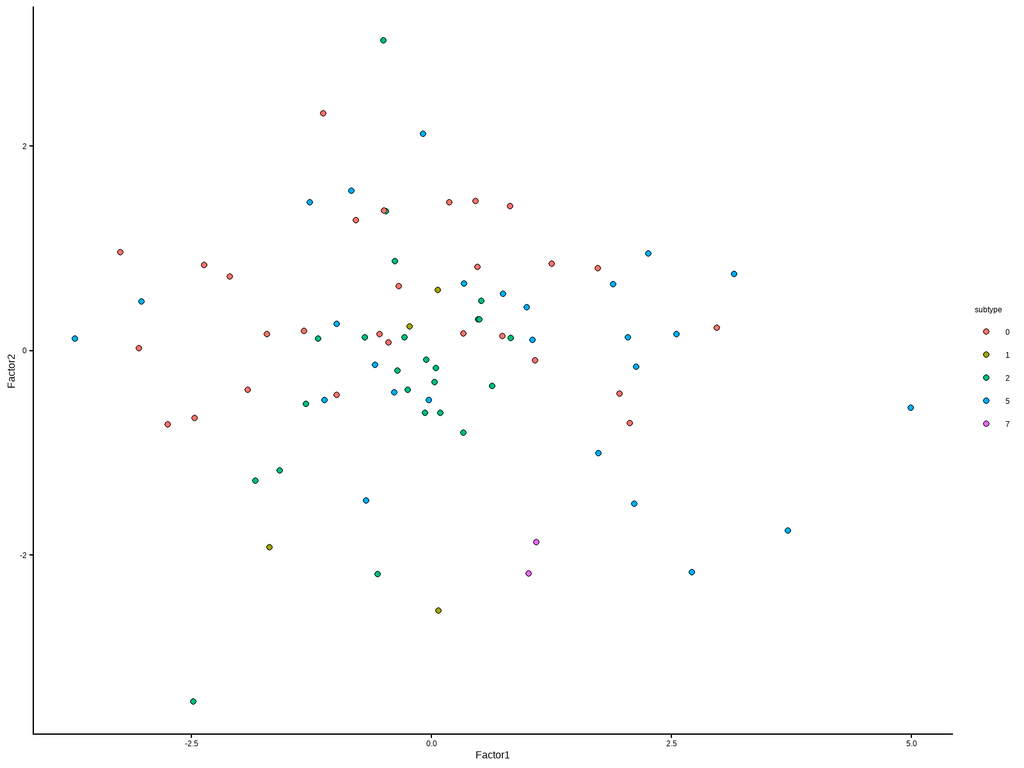

**Co vidíme:** Subtyp 7 má nejvyšší medián Factor1 1.05, Subtyp 0 nejnižší -0.47 (Δ≈1.52).

**Jak to číst:** Oddělení subtypů na faktorové ose naznačuje, že latentní faktor zachycuje biologicky odlišné profily.

**Co to znamená pro myozitidy:** Heterogenita subtypů IIM je v literatuře dobře popsaná; rozdílné faktory mohou odrážet variabilitu v aktivitě nemoci, svalové síle nebo přidružených orgánových projevech.

**Co je nejisté:** Překryv subtypů může být dán malým počtem vzorků v některých skupinách.

**Jaký další krok:** Spojit faktory s klinickými endpointy (MMT8, HAQ, CK) a ověřit biologickou interpretaci.

### 5.8.2 Faktory 3–4 – rozložení podle subtypu

[figure not shown]

**Co vidíme:** Subtyp 5 má nejvyšší medián Factor3 0.29, Subtyp 7 nejnižší -0.94 (Δ≈1.24).

**Jak to číst:** Faktory 3–4 zachycují další, jemnější osu variability, která může být nezávislá na hlavních faktorech.

**Co to znamená pro myozitidy:** Sekundární faktory mohou odpovídat specifickým doménám (např. únava, režimová stabilita), které nejsou plně zachyceny faktorem 1–2.

**Co je nejisté:** Interpretace vyšších faktorů je citlivější na šum a menší počty ve skupinách.

**Jaký další krok:** Provést biologickou anotaci top vah pro faktory 3–4.

### 5.8.3 Faktory – rozložení podle M0/M6

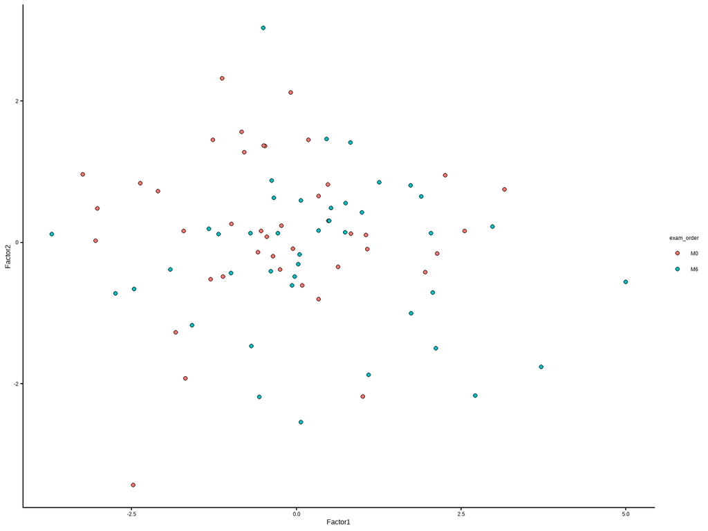

**Co vidíme:** M0 má medián Factor1 -0.40, M6 0.07 (Δ=0.47). U Factor2 je M0 0.16 a M6 0.12 (Δ=-0.04).

**Jak to číst:** Směr posunu M0→M6 ukazuje, zda se latentní profil pacientů mění v čase.

**Co to znamená pro myozitidy:** V literatuře je po léčbě očekáván posun směrem k lepší funkci a nižší aktivitě nemoci; posun faktorů tedy může odrážet klinickou odpověď.

**Co je nejisté:** Časový posun může být heterogenní mezi subtypy.

**Jaký další krok:** Propojit změnu faktorů s individuální odpovědí na terapii.

### 5.8.4 Faktory 3–4 – rozložení podle M0/M6

[figure not shown]

**Co vidíme:** M0 má medián Factor3 -0.21, M6 0.06 (Δ=0.26). U Factor4 je M0 0.37 a M6 -0.44 (Δ=-0.81).

**Jak to číst:** Posun M0→M6 na sekundárních faktorech může ukazovat jemnější změny režimu nebo symptomů.

**Co to znamená pro myozitidy:** Pokud se faktory 3–4 mění s časem, může to souviset s únavou, adaptací na léčbu nebo změnami denního režimu.

**Co je nejisté:** Změny mohou být malé a citlivé na chybějící data.

**Jaký další krok:** Porovnat trend faktorů 3–4 s klinickými endpointy a se změnami aktigrafie.

### 5.8.5 UMAP na faktorech

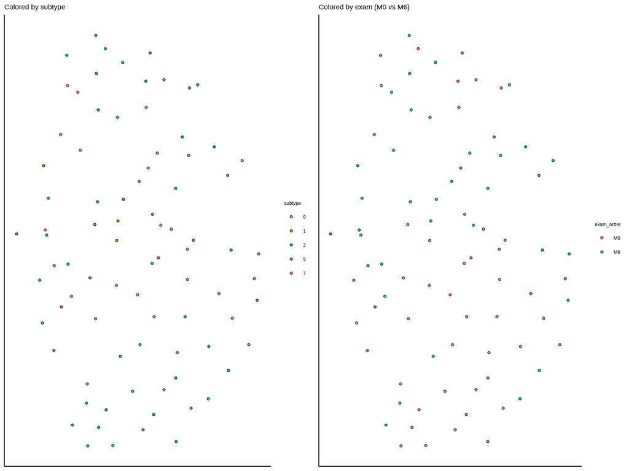

**Co vidíme:** Centroidy M0 a M6 v UMAP prostoru jsou vzdálené ~1.05.

**Jak to číst:** Větší vzdálenost centroidů značí globální posun v latentním prostoru mezi M0 a M6.

**Co to znamená pro myozitidy:** Pokud se M0 a M6 oddělují, může to reflektovat klinickou odpověď nebo změnu aktivity nemoci.

**Co je nejisté:** UMAP je nelineární a citlivý na parametry; malé posuny mohou být artefakt.

**Jaký další krok:** Ověřit stabilitu UMAP při různých seed/parametrech a porovnat s lineárními faktory.